# Rcpp

Lecture 26

Dr. Colin Rundel

## Rcpp

> The Rcpp package integrates R and C++ via R functions and a (header-only) C++ library.

> All underlying R types and objects, i.e., everything a `SEXP` represents internally in R, are matched to corresponding C++ objects. This covers anything from vectors, matrices or lists to environments, functions and more. Each `SEXP` variant is automatically mapped to a dedicated C++ class. For example, numeric vectors are represented as instances of the `Rcpp::NumericVector` class, environments are represented as instances of `Rcpp::Environment`, functions are represented as `Rcpp::Function`, etc …

From “Extending R with C++ -”A Brief Introduction to Rcpp”:

> R has always provided an application programming interface (API) for extensions. Based on the C language, it uses a number of macros and other low-level constructs to exchange data structures between the R process and any dynamically-loaded component modules authors added to it. With the introduction of the Rcpp package, and its later refinements, this process has become considerably easier yet also more robust. By now, Rcpp has become the most popular extension mechanism for R.

## C++ Types

| Type | Size | Description | Value Range |
| --- | --- | --- | --- |
| `bool` | 1* | Logical value: `true` or `false` | `true` or `false` |
| `char` | 8 | Character (ASCII or UTF8) | $\pm 127$ |
| `short int` | 16 | Small integers | $\pm 3.27 \cdot 10^4$ |
| `int` | 32 | Medium integers | $\pm 2.14 \cdot 10^9$ |
| `long int` | 64 | Large integers | $\pm 9.22 \cdot 10^18$ |
| `float` | 32 | Small floating point value | $\pm 10^{-38}$ to $\pm 10^{38}$ |
| `double` | 64 | Large floating point value | $\pm 10^{-308}$ to $\pm 10^{308}$ |

+ many more

## R types vs C++ types

All of the basic types in R are vectors by default, in C++ the types we just discussed are all scalar. So it is necessary to have one more level of abstraction to translate between the two. Rcpp provides for this with several built in classes:

| C++ type (scalar) | Rcpp Class | R type (`typeof`) |
| --- | --- | --- |
| `int` | `Rcpp::IntegerVector` | `integer` |
| `double` | `Rcpp::NumericVector` | `numeric` |
| `bool` | `Rcpp::LogicalVector` | `logical` |
| `std::string` | `Rcpp::CharacterVector` | `character` |
| `char` | `Rcpp::RawVector` | `raw` |
| `std::complex<double>` | `Rcpp::ComplexVector` | `complex` |
|  | `Rcpp::List` | `list` |
|  | `Rcpp::Environment` | `environment` |
|  | `Rcpp::Function` | `function` |
|  | `Rcpp::XPtr` | `externalptr` |
|  | `Rcpp::S4` | `S4` |

## Trying things out

Rcpp provides some helpful functions for trying out simple C++ expressions (`evalCpp`), functions (`cppFunction`), or cpp files (`sourceCpp`). It is even possible to include C++ code in Rmd / qmd documents using the Rcpp [engine](https://bookdown.org/yihui/rmarkdown/language-engines.html#rcpp).

```r
evalCpp("2+2")
```

```
[1] 4
```

```r
evalCpp("2+2") |> typeof()
```

```
[1] "integer"
```

```r
evalCpp("2+2.") |> typeof()
```

```
[1] "double"
```

## What’s happening?

```r
evalCpp("2+2", verbose = TRUE, rebuild = TRUE)
```

```
Generated code for function definition:
--------------------------------------------------------

#include <Rcpp.h>

using namespace Rcpp;

// [[Rcpp::export]]
SEXP get_value(){ return wrap( 2+2 ) ; }

Generated extern "C" functions
--------------------------------------------------------


#include <Rcpp.h>
#ifdef RCPP_USE_GLOBAL_ROSTREAM
Rcpp::Rostream<true>&  Rcpp::Rcout = Rcpp::Rcpp_cout_get();
Rcpp::Rostream<false>& Rcpp::Rcerr = Rcpp::Rcpp_cerr_get();
#endif

// get_value
SEXP get_value();
RcppExport SEXP sourceCpp_1_get_value() {
BEGIN_RCPP
    Rcpp::RObject rcpp_result_gen;
    Rcpp::RNGScope rcpp_rngScope_gen;
    rcpp_result_gen = Rcpp::wrap(get_value());
    return rcpp_result_gen;
END_RCPP
}

Generated R functions
-------------------------------------------------------

`.sourceCpp_1_DLLInfo` <- dyn.load('/private/var/folders/v7/wrxd7cdj6l5gzr0191__m9lr0000gr/T/Rtmp0CfIUI/sourceCpp-aarch64-apple-darwin20-1.1.0/sourcecpp_623926f7ac34/sourceCpp_5.so')

get_value <- Rcpp:::sourceCppFunction(function() {}, FALSE, `.sourceCpp_1_DLLInfo`, 'sourceCpp_1_get_value')

rm(`.sourceCpp_1_DLLInfo`)

Building shared library
--------------------------------------------------------

DIR: /private/var/folders/v7/wrxd7cdj6l5gzr0191__m9lr0000gr/T/Rtmp0CfIUI/sourceCpp-aarch64-apple-darwin20-1.1.0/sourcecpp_623926f7ac34

/Library/Frameworks/R.framework/Resources/bin/R CMD SHLIB --preclean -o 'sourceCpp_5.so' 'file623918cea60d.cpp'
```

```
[1] 4
```

## C++ functions as R functions

```r
cppFunction('
  double cpp_mean(double x, double y) {
    return (x+y)/2;
  }
')
```

```r
cpp_mean
```

```
function (x, y)
.Call(<pointer: 0x1142cda30>, x, y)
```

```r
cpp_mean(1,2)
```

```
[1] 1.5
```

```r
cpp_mean(TRUE,2L)
```

```
[1] 1.5
```

```r
cpp_mean(1,"A")
```

```
Error: Not compatible with requested type: [type=character; target=double].
```

```r
cpp_mean(c(1,2), c(1,2))
```

```
Error: Expecting a single value: [extent=2].
```

## Using `sourceCpp`

This allows for an entire `.cpp` source file to be compiled and loaded into R. This is generally the preferred way of working with C++ code and is well supported by RStudio (i.e. provides syntax highlights, tab completion, etc.)

- Make sure to include the Rcpp header

```cpp
#include <Rcpp.h>
```

- If you don’t like typing `Rcpp::` everywhere, include the namespace

```cpp
using namespace Rcpp;
```

- Specify any desired plugins with

```cpp
// [[Rcpp::plugins(cpp11)]]
```

- Prefix any functions that will be exported with R with

```cpp
// [[Rcpp::export]]
```

- Testing code can be included using an R code block at the end:

```cpp
/*** R
# This R code will be run automatically
*/
```

## Example

The following would be avaiable as a file called `mean.cpp` or similar.

```cpp
#include <Rcpp.h>

//[[Rcpp::plugins(cpp11)]]

//[[Rcpp::export]]
double cpp_mean(double x, double y) {
  return (x+y)/2;
}

/*** R
bench::mark(
  cpp_mean(1, 2),
  mean(c(1, 2))
)
*/
```

```r
sourceCpp("mean.cpp")
```

```
> bench::mark(cpp_mean(1, 2), mean(c(1, 2)))
# A tibble: 2 × 13
  expression    min   median `itr/sec` mem_alloc `gc/sec` n_itr  n_gc total_time
  <bch:expr>  <bch> <bch:tm>     <dbl> <bch:byt>    <dbl> <int> <dbl>   <bch:tm>
1 cpp_mean(1… 164ns 450.99ns  1679535.        0B        0 10000     0     5.95ms
2 mean(c(1, … 820ns   1.19µs   828380.        0B        0 10000     0    12.07ms
# ℹ 4 more variables: result <list>, memory <list>, time <list>, gc <list>
```

## `for` loops

In C & C++ `for` loops are traditionally constructed as,

```c
for(initialization; end condition; increment) {
  //...loop code ..
}
```

```cpp
#include <Rcpp.h>

//[[Rcpp::export]]
double cpp_mean(Rcpp::NumericVector x) {
  double sum = 0.0;
  for(int i=0; i != x.size(); i++) {
    sum += x[i];
  }
  return sum/x.size();
}
```

```r
cpp_mean(1:10)
```

```
[1] 5.5
```

## Range based for loops (C++11)

Since the adoption of the C++11 standard there is an alternative for loop syntax,

```cpp
#include <Rcpp.h>
//[[Rcpp::plugins(cpp11)]]

//[[Rcpp::export]]
double cpp11_mean(Rcpp::NumericVector x) {
  double sum = 0.0;
  for(auto v : x) {
    sum += v;
  }

  return sum/x.size();
}
```

```r
cpp11_mean(1:10)
```

```
[1] 5.5
```

## Available plugins?

```r
ls(envir = Rcpp:::.plugins)
```

```
 [1] "cpp0x"         "cpp11"         "cpp14"         "cpp17"
 [5] "cpp1y"         "cpp1z"         "cpp20"         "cpp23"
 [9] "cpp26"         "cpp2a"         "cpp2b"         "cpp98"
[13] "openmp"        "unwindProtect"
```

## Rcpp Sugar

Rcpp also attempts to provide many of the base R functions within the C++ scope, generally these are referred to as Rcpp Sugar. More details can be found [here](http://dirk.eddelbuettel.com/code/rcpp/Rcpp-sugar.pdf) or by looking at the Rcpp source.

```cpp
#include <Rcpp.h>
//[[Rcpp::plugins(cpp11)]]

//[[Rcpp::export]]
double rcpp_mean(Rcpp::NumericVector x) {
  return Rcpp::mean(x);
}
```

```r
rcpp_mean(1:10)
```

```
[1] 5.5
```

## Edge cases

```r
x = c(1:10,NA)
typeof(x)
```

```
[1] "integer"
```

```r
mean(x)
```

```
[1] NA
```

```r
cpp_mean(x)
```

```
[1] NA
```

```r
cpp11_mean(x)
```

```
[1] NA
```

```r
rcpp_mean(x)
```

```
[1] NA
```

```r
x = c(1:10,NA_real_)
typeof(x)
```

```
[1] "double"
```

```r
mean(x)
```

```
[1] NA
```

```r
cpp_mean(x)
```

```
[1] NA
```

```r
cpp11_mean(x)
```

```
[1] NA
```

```r
rcpp_mean(x)
```

```
[1] NA
```

```r
y = c(1:10,Inf)
typeof(y)
```

```
[1] "double"
```

```r
mean(y)
```

```
[1] Inf
```

```r
cpp_mean(y)
```

```
[1] Inf
```

```r
cpp11_mean(y)
```

```
[1] Inf
```

```r
rcpp_mean(y)
```

```
[1] Inf
```

## Integer mean

```cpp
#include <Rcpp.h>
//[[Rcpp::plugins(cpp11)]]

//[[Rcpp::export]]
double cpp_imean(Rcpp::IntegerVector x) {
  double sum = 0.0;
  for(int i=0; i != x.size(); i++) {
    sum += x[i];
  }

  return sum/x.size();
}

//[[Rcpp::export]]
double cpp11_imean(Rcpp::IntegerVector x) {
  double sum = 0.0;
  for(auto v : x) {
    sum += v;
  }

  return sum/x.size();
}

//[[Rcpp::export]]
double rcpp_imean(Rcpp::IntegerVector x) {
  return Rcpp::mean(x);
}
```

## Integer edge cases

```r
x = c(1:10,NA)
typeof(x)
```

```
[1] "integer"
```

```r
mean(x)
```

```
[1] NA
```

```r
cpp_imean(x)
```

```
[1] -195225781
```

```r
cpp11_imean(x)
```

```
[1] -195225781
```

```r
rcpp_imean(x)
```

```
[1] NA
```

```r
x = c(1:10,NA_real_)
typeof(x)
```

```
[1] "double"
```

```r
mean(x)
```

```
[1] NA
```

```r
cpp_imean(x)
```

```
[1] -195225781
```

```r
cpp11_imean(x)
```

```
[1] -195225781
```

```r
rcpp_imean(x)
```

```
[1] NA
```

```r
y = c(1:10,Inf)
typeof(y)
```

```
[1] "double"
```

```r
mean(y)
```

```
[1] Inf
```

```r
cpp_imean(y)
```

```
[1] -195225781
```

```r
cpp11_imean(y)
```

```
[1] -195225781
```

```r
rcpp_imean(y)
```

```
[1] NA
```

## Missing values - C++ Scalars

From Hadley’s [Adv-R](http://adv-r.had.co.nz) [Rcpp chapter](http://adv-r.had.co.nz/Rcpp.html#rcpp-na),

```cpp
#include <Rcpp.h>

// [[Rcpp::export]]
Rcpp::List scalar_missings() {
  int int_s          = NA_INTEGER;
  Rcpp::String chr_s = NA_STRING;
  bool lgl_s         = NA_LOGICAL;
  double num_s       = NA_REAL;

  return Rcpp::List::create(int_s, chr_s, lgl_s, num_s);
}
```

```r
scalar_missings() |> str()
```

```
List of 4
 $ : int NA
 $ : chr NA
 $ : logi TRUE
 $ : num NA
```

## Missing values - Rcpp Vectors

```cpp
#include <Rcpp.h>

// [[Rcpp::export]]
Rcpp::List vector_missing() {
  return Rcpp::List::create(
    Rcpp::NumericVector::create(NA_REAL),
    Rcpp::IntegerVector::create(NA_INTEGER),
    Rcpp::LogicalVector::create(NA_LOGICAL),
    Rcpp::CharacterVector::create(NA_STRING)
  );
}
```

```r
vector_missing() |> str()
```

```
List of 4
 $ : num NA
 $ : int NA
 $ : logi NA
 $ : chr NA
```

## Performance

```r
r_mean = function(x) {
  sum = 0
  for(v in x) {
    sum = sum + v
  }
  sum / length(x)
}
```

```r
y = rnorm(1e6)
bench::mark(
  mean(y), r_mean(y), cpp_mean(y), cpp11_mean(y), rcpp_mean(y)
)
```

```
# A tibble: 5 × 6
  expression         min   median `itr/sec` mem_alloc `gc/sec`
  <bch:expr>    <bch:tm> <bch:tm>     <dbl> <bch:byt>    <dbl>
1 mean(y)       950.17µs 969.65µs     1021.        0B        0
2 r_mean(y)        6.1ms   6.48ms      155.    19.5KB        0
3 cpp_mean(y)     4.61ms    4.9ms      205.        0B        0
4 cpp11_mean(y) 473.84µs 484.99µs     2050.        0B        0
5 rcpp_mean(y)    1.06ms   1.08ms      923.        0B        0
```

## `bench::press`

```r
b = bench::press(
  n = 10^c(3:7),
  {
    y = sample(rnorm(n))
    bench::mark(
      mean(y), r_mean(y), cpp_mean(y), cpp11_mean(y), rcpp_mean(y)
    )
  }
)
```

```
Running with:
         n
```

```
1     1000
```

```
2    10000
```

```
3   100000
```

```
4  1000000
```

```
5 10000000
```

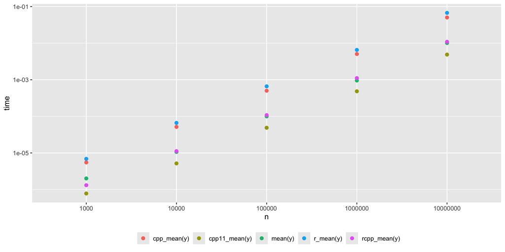

## Creating a `list`

```cpp
#include <Rcpp.h>

// [[Rcpp::export]]
Rcpp::List make_list(int n) {
  return Rcpp::List::create(
    Rcpp::Named("norm") = Rcpp::rnorm(n, 0, 1),
    Rcpp::Named("beta") = Rcpp::rbeta(n, 1, 1),
    Rcpp::IntegerVector::create(1,2,3,4,5, NA_INTEGER)
  );
}
```

```r
make_list(10)
```

```
$norm
 [1]  1.9488167 -0.8285304 -1.1097544 -0.5550965  1.2926654  1.2270469
 [7] -2.9024726 -0.1560244 -0.7628897 -0.9276166

$beta
 [1] 0.9387534068 0.5661279624 0.4984754021 0.4521797032 0.7545363114
 [6] 0.0000225238 0.0341585791 0.1516264656 0.1550719612 0.5204840924

[[3]]
[1]  1  2  3  4  5 NA
```

## Creating a `data.frame`

```cpp
#include <Rcpp.h>

// [[Rcpp::export]]
Rcpp::DataFrame make_df(int n) {
  return Rcpp::DataFrame::create(
    Rcpp::Named("norm") = Rcpp::rnorm(n, 0, 1),
    Rcpp::Named("beta") = Rcpp::rbeta(n, 1, 1)
  );
}
```

```r
make_df(10)
```

```
          norm      beta
1  -1.59743101 0.8389083
2  -0.44002009 0.4046016
3   0.04101498 0.4530328
4  -2.22006170 0.9445844
5   0.91717044 0.9382699
6  -0.62993819 0.2152116
7  -2.09899910 0.7313789
8   2.75929305 0.2751544
9  -0.60135051 0.6822893
10 -1.34614376 0.4784344
```

## Creating a `tbl`

```cpp
#include <Rcpp.h>

// [[Rcpp::export]]
Rcpp::DataFrame make_tbl(int n) {
  Rcpp::DataFrame df = Rcpp::DataFrame::create(
    Rcpp::Named("norm") = Rcpp::rnorm(n, 0, 1),
    Rcpp::Named("beta") = Rcpp::rbeta(n, 1, 1)
  );
  df.attr("class") = Rcpp::CharacterVector::create("tbl_df", "tbl", "data.frame");

  return df;
}
```

```r
make_tbl(10)
```

```
# A tibble: 10 × 2
      norm  beta
     <dbl> <dbl>
 1  0.0291 0.569
 2 -2.18   0.951
 3  0.262  0.875
 4  0.0244 0.710
 5  0.520  0.602
 6 -1.20   0.771
 7  1.06   0.152
 8 -0.400  0.152
 9 -0.160  0.436
10 -0.769  0.613
```

## Printing

R has some weird behavior when it comes to printing text from C++, Rcpp has function that resolves this, `Rcout`

```cpp
#include <Rcpp.h>

// [[Rcpp::export]]
void n_hello(int n) {
  for(int i=0; i!=n; ++i) {
    Rcpp::Rcout << i+1 << ". Hello world!\n";
  }
}
```

```r
n_hello(5)
```

```
1. Hello world!
2. Hello world!
3. Hello world!
4. Hello world!
5. Hello world!
```

## Printing `NA`s

```cpp
#include <Rcpp.h>

// [[Rcpp::export]]
void print_na() {
  Rcpp::Rcout << "NA_INTEGER : " << NA_INTEGER << "\n";
  Rcpp::Rcout << "NA_STRING  : " << NA_STRING  << "\n";
  Rcpp::Rcout << "NA_LOGICAL : " << NA_LOGICAL << "\n";
  Rcpp::Rcout << "NA_REAL    : " << NA_REAL    << "\n";
}
```

```r
print_na()
```

```
NA_INTEGER : -2147483648
NA_STRING  : 0x12580c000
NA_LOGICAL : -2147483648
NA_REAL    : nan
```

## SEXP Conversion

Rcpp attributes provides a bunch of convenience tools that handle much of the conversion from R SEXP’s to C++ / Rcpp types and back. Some times it is necessary to handle this directly.

```cpp
#include <Rcpp.h>

// [[Rcpp::export]]
SEXP as_wrap(SEXP input) {
  Rcpp::NumericVector r = Rcpp::as<Rcpp::NumericVector>(input);
  Rcpp::NumericVector rev_r = Rcpp::rev(r);

  return Rcpp::wrap(rev_r);
}
```

```r
as_wrap(1:10)
```

```
 [1] 10  9  8  7  6  5  4  3  2  1
```

```r
as_wrap(c(1,2,3))
```

```
[1] 3 2 1
```

```r
as_wrap(c("A","B","C"))
```

```
Error: Not compatible with requested type: [type=character; target=double].
```

# RcppArmadillo

## Armadillo

[figure not shown]

- Developed by Dr. Conrad Sanderson and Dr Ryan Curtin
- Template based linear algebra library with high level syntax (like R or Matlab)
- Heavy lifting is (mostly) handled by LAPACK (i.e. benefits from OpenBLAS)
- Supports vectors, matrices, and cubes in dense or sparse format
- Some builtin expression optimization via template meta-programming
- Header only or shared library versions available

## Basic types

Armadillo has 4 basic (dense) templated types:

```cpp
arma::Col<type>,
arma::Row<type>,
arma::Mat<type>,
arma::Cube<type>
```

These types can be specialized using one of the following data types:

```cpp
float, double,
std::complex<float>, std::complex<double>,
short, int, long,
unsigned short, unsigned int, unsigned long
```

## typedef Shortcuts

For convenience the following typedefs are defined:

- Vectors:

```cpp
arma::vec     = arma::colvec     =  arma::Col<double>
arma::dvec    = arma::dcolvec    =  arma::Col<double>
arma::fvec    = arma::fcolvec    =  arma::Col<float>
arma::cx_vec  = arma::cx_colvec  =  arma::Col<cx_double>
arma::cx_dvec = arma::cx_dcolvec =  arma::Col<cx_double>
arma::cx_fvec = arma::cx_fcolvec =  arma::Col<cx_float>
arma::uvec    = arma::ucolvec    =  arma::Col<uword>
arma::ivec    = arma::icolvec    =  arma::Col<sword>
```

- Matrices

```cpp
arma::mat     = arma::Mat<double>
arma::dmat    = arma::Mat<double>
arma::fmat    = arma::Mat<float>
arma::cx_mat  = arma::Mat<cx_double>
arma::cx_dmat = arma::Mat<cx_double>
arma::cx_fmat = arma::Mat<cx_float>
arma::umat    = arma::Mat<uword>
arma::imat    = arma::Mat<sword>
```

## RcppArmadillo

- Written and maintained by Dirk Eddelbuettel, Romain Francois, Doug Bates and Binxiang Ni
- Provides the header only version of Armadillo along with additional wrappers
  - Wrappers provide easy conversion between Rcpp types and Armadillo types
  - Enables use of Rcpp attributes and related tools
- Include the following in your C++ code:

```cpp
// [[Rcpp::depends(RcppArmadillo)]]
#include <RcppArmadillo.h>
```

## Example Program

```cpp
// [[Rcpp::depends(RcppArmadillo)]]
#include <RcppArmadillo.h>

// [[Rcpp::export]]
arma::mat test_randu(int n, int m) {
  arma::mat A = arma::randu<arma::mat>(n,m);
  return A;
}
```

```r
test_randu(4,5)
```

```
          [,1]      [,2]      [,3]      [,4]      [,5]
[1,] 0.1667928 0.6575326 0.5676687 0.6074325 0.2540894
[2,] 0.3053677 0.6481933 0.9097105 0.7308671 0.9109742
[3,] 0.3001430 0.7471385 0.6986718 0.9681653 0.3233815
[4,] 0.8806327 0.5012938 0.3641878 0.6065834 0.2796219
```

```r
test_randu(3,1)
```

```
          [,1]
[1,] 0.9545359
[2,] 0.6865738
[3,] 0.7338450
```

## arma class attributes

| Attribute | Description |
| --- | --- |
| `.n_rows` | number of rows; present in Mat, Col, Row, Cube, field and SpMat |
| `.n_cols` | number of columns; present in Mat, Col, Row, Cube, field and SpMat |
| `.n_elem` | total number of elements; present in Mat, Col, Row, Cube, field and SpMat |
| `.n_slices` | number of slices; present in Cube and field |

```cpp
// [[Rcpp::depends(RcppArmadillo)]]
#include <RcppArmadillo.h>

// [[Rcpp::export]]
void test_attr(arma::mat m) {
  Rcpp::Rcout << "m.n_rows = " << m.n_rows << "\n";
  Rcpp::Rcout << "m.n_cols = " << m.n_cols << "\n";
  Rcpp::Rcout << "m.n_elem = " << m.n_elem << "\n";
}
```

```r
test_attr(matrix(0, 3, 3))
```

```
m.n_rows = 3
m.n_cols = 3
m.n_elem = 9
```

```r
test_attr(matrix(1, 4, 5))
```

```
m.n_rows = 4
m.n_cols = 5
m.n_elem = 20
```

```r
test_attr(1:10)
```

```
Error: Not a matrix.
```

```r
test_attr(as.matrix(1:10))
```

```
m.n_rows = 10
m.n_cols = 1
m.n_elem = 10
```

## Element access

For an `arma::vec v`,

| Call | Description |
| --- | --- |
| `v(i)` | Access the `i`-th element with bounds checking |
| `v.at(i)` | Access the `i`-th element without bounds checking |
| `v[i]` | Access the `i`-th element without bounds checking |

For an `arma::mat m`,

| Call | Description |
| --- | --- |
| `m(i)` | Access the `i`-th element, treating object as flat and in column major order |
| `m(i,j)` | Access the element in `i`-th row and `j`-th column with bounds checking |
| `m.at(i,j)` | Access the element in `i`-th row and `j`-th column without bounds checking |

## Element access - Cubes

For an `arma::cube c`,

| Call | Description |
| --- | --- |
| `c(i)` | Access the i-th element, treating object as flat and in column major order |
| `c(i,j,k)` | Access the element in `i`-th row, `j`-th column, and `k`-th slice with bounds checking |
| `c.at(i,j,k)` | Access the element in `i`-th row, `j`-th column, and `k`-th slice without bounds checking |

## Data Organization

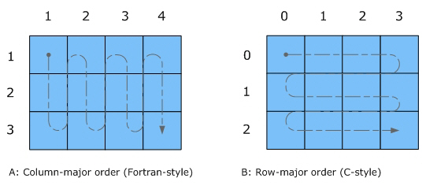

[Image source](https://scc.ustc.edu.cn/zlsc/tc4600/intel/2017.0.098/mkl/common/mkl_userguide/GUID-ABCC618B-43C4-4DCD-ADA2-6F061B5116CD.html)

```cpp
// [[Rcpp::depends(RcppArmadillo)]]
#include <RcppArmadillo.h>

// [[Rcpp::export]]
void test_order(arma::mat m) {
  for(int i=0; i!=m.n_elem; ++i) {
    Rcpp::Rcout << m(i) << " ";
  }
  Rcpp::Rcout << "\n";
}
```

```r
m = matrix(1:9, 3, 3)
```

```r
c(m)
```

```
[1] 1 2 3 4 5 6 7 8 9
```

```r
test_order(m)
```

```
1 2 3 4 5 6 7 8 9
```

```r
c(t(m))
```

```
[1] 1 4 7 2 5 8 3 6 9
```

```r
test_order(t(m))
```

```
1 4 7 2 5 8 3 6 9
```

## `fastLm` example

```cpp
// [[Rcpp::depends(RcppArmadillo)]]
#include <RcppArmadillo.h>

// [[Rcpp::export]]
Rcpp::List fastLm(const arma::mat& X, const arma::colvec& y) {
    int n = X.n_rows, k = X.n_cols;

    arma::colvec coef = arma::solve(X, y);    // fit model y ~ X
    arma::colvec res  = y - X*coef;           // residuals

    // std.errors of coefficients
    double s2 = std::inner_product(res.begin(), res.end(), res.begin(), 0.0)/(n - k);

    arma::colvec std_err = arma::sqrt(s2 * arma::diagvec(arma::pinv(arma::trans(X)*X)));

    return Rcpp::List::create(
      Rcpp::Named("coefficients") = coef,
      Rcpp::Named("stderr")       = std_err,
      Rcpp::Named("df.residual")  = n - k
    );
}
```

From fastLm.cpp

```r
library(dplyr)
n=1e5
d = tibble(
  x1 = rnorm(n),
  x2 = rnorm(n),
  x3 = rnorm(n),
  x4 = rnorm(n),
  x5 = rnorm(n),
) %>%
  mutate(
    y = 3 + x1 - x2 + 2*x3 -2*x4 + 3*x5 - rnorm(n)
  )
```

```r
res = bench::press(
  size = c(100, 1000, 10000, 100000),
  {
    d = d[seq_len(size),]
    X = model.matrix(y ~ ., d)
    y = as.matrix(d$y)

    bench::mark(
      lm(y~., data=d),
      lm.fit(X,y),
      .lm.fit(X,y),
      fastLm(X,y),
      check = FALSE
    )
  }
)
```

```
Running with:
    size
```

```
1    100
```

```
2   1000
```

```
3  10000
```

```
4 100000
```

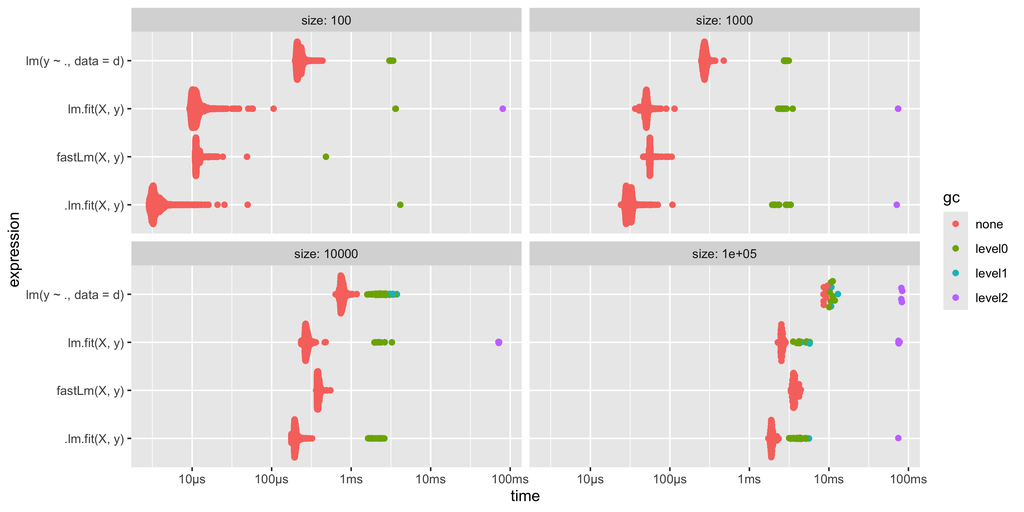

# MVN Example

## Multivariate Normal Distribution - Review

For an $n$-dimension multivate normal distribution with covariance $\boldsymbol{\Sigma}$ can be written as

$$\underset{n \times 1}{\boldsymbol{Y}} \sim N(\underset{n \times 1}{\boldsymbol{\mu}}, \; \underset{n \times n}{\boldsymbol{\Sigma}})$$

where $\big\{\boldsymbol{\Sigma}\big\}_{ij} = \rho_{ij} \sigma_i \sigma_j$

$$\begin{pmatrix}
y_1\\ y_2\\ \vdots\\ y_n
\end{pmatrix}
\sim N\left(
\begin{pmatrix}
\mu_1\\ \mu_2\\ \vdots\\ \mu_n
\end{pmatrix}, \,
\begin{pmatrix}
\rho_{11}\sigma_1\sigma_1 & \rho_{12}\sigma_1\sigma_2 & \cdots & \rho_{1n}\sigma_1\sigma_n \\
\rho_{21}\sigma_2\sigma_1 & \rho_{22}\sigma_2\sigma_2 & \cdots & \rho_{2n}\sigma_2\sigma_n\\
\vdots & \vdots & \ddots & \vdots \\
\rho_{n1}\sigma_n\sigma_1 & \rho_{n2}\sigma_n\sigma_2 & \cdots & \rho_{nn}\sigma_n\sigma_n \\
\end{pmatrix}
\right)$$

## Multivariate Normal Distribution - Sampling

To generate draws from an $n$-dimensional multivate normal with mean $\underset{n \times 1}{\boldsymbol{\mu}}$ and covariance matrix $\underset{n \times n}{\boldsymbol{\Sigma}}$,

- Find a matrix $\underset{n \times n}{\boldsymbol{A}}$ such that $\boldsymbol{\Sigma} = \boldsymbol{A}\,\boldsymbol{A}^t$
  - most often we use $\boldsymbol{A} = \text{Chol}(\boldsymbol{\Sigma})$ where $\boldsymbol{A}$ is a lower triangular matrix.
- Draw $n$ iid unit normals, $N(0,1)$, as $\underset{n \times 1}{\boldsymbol{z}}$
- Obtain multivariate normal draws using
  $$\underset{n \times 1}{\boldsymbol{y}} = \underset{n \times 1}{\boldsymbol{\mu}} + \underset{n \times n}{\boldsymbol{A}} \, \underset{n \times 1}{\boldsymbol{z}}$$

## Multivariate Normal Distribution - Density

For the $n$ dimensional multivate normal given on the last slide, its density is given by

$$f\big(\boldsymbol{Y} | \boldsymbol{\mu}, \boldsymbol{\Sigma}\big) = (2\pi)^{-n/2} \; \det(\boldsymbol{\Sigma})^{-1/2} \; \exp{\left(-\frac{1}{2} \underset{1 \times n}{(\boldsymbol{Y}-\boldsymbol{\mu})'} \underset{n \times n}{\boldsymbol{\Sigma}^{-1}} \underset{n \times 1}{(\boldsymbol{Y}-\boldsymbol{\mu})}\right)}$$

and its log density is given by

$$\log f\big(\boldsymbol{Y} | \boldsymbol{\mu}, \boldsymbol{\Sigma}\big) = -\frac{n}{2} \log 2\pi - \frac{1}{2} \log \det(\boldsymbol{\Sigma}) - \frac{1}{2} \underset{1 \times n}{(\boldsymbol{Y}-\boldsymbol{\mu})'} \underset{n \times n}{\boldsymbol{\Sigma}^{-1}} \underset{n \times 1}{(\boldsymbol{Y}-\boldsymbol{\mu})}$$